# Project 4 Report - Movie Recommendation

##### Which similarity metric you use?

- **Ans**.  
  Three popular mechanism of similiarity metric are using Jaccard Index (Jaccard Similarity Coeff), Cosine Similarity, and Euclidean Similarity.

  **Jaccard Similarity** = J (A, B) = |A INTERESECTION B| / |A UNION B| and distance would be 1-similarity.  
  **Cosine Similarity** = cos (Theta) = A.B / ||A|| ||B|| i.e represented using the dot product and magnitude.  
  **Euclidean Similarity** = 1 / d(A, B)

It seems that a Jaccard distance could give wrong assumption in comparison to the distance with other users and hence it seemed less likely an option for us to choose as it could likely end up in intuitively wrong assumptions. In order to fix this, it seems the original rating have to be rounded in a certain way, say ratings 3 to 5 are assigned value 1, and 1 to 2 are NA’s (unrated). Doing such manipulations can help make correct calculations.

For our app, we have used Cosine Similarity. The cosine similarity metric would give us an angle between two users. Larger cosine implies smaller angle and therefore smaller distance. Smaller distance would mean user preferences are closer compared to other user distances. It would still perform correctly on the rounding off logic as mentioned above for Jaccard distance. Only drawback of cosine distance is it would treat NA’s as 0 and that could lead to considering rating as poorly rated movie.

Euclidean distance similarity simply computes the L2 distance between the vectors.

##### If you say prediction is based on a “weighted average”, then explain what weights you use.

- **Ans**.  
  For most of the of the systems we did take top users by averaging the ratings but for System 1 specifically have used an additional weighted-rating metric.

$$WR = (\frac{v}{v+m}) * R + (\frac{m}{v+m})*C$$

- r = mean rating
- v = number votes
- m = min votes to be in top n
- C = mean vote across genre

In case of UBCF and IBCF, the weights are basically give by utilizing the similarity measures as shown below where $s_{ai}$ is the similarity between the active user $u_{a}$ and user $u_{i}$ in the neighborhood.

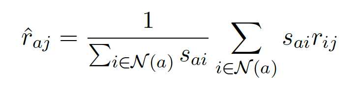

Ubcf Similiarity Weight being added here

##### Will you still have missing values after running the algorithm? If so, how you handle those missing values?

- **Ans.**  
  The “ratings” type would return the normalized predicted ratings and would replace the ones set in input as NA’s. “ratingMatrix” on the other hand gives us a complete rating matrix without NA’s and we have used that for further calculations.

### References

- https://cran.r-project.org/web/packages/recommenderlab/vignettes/recommenderlab.pdf
- https://youtu.be/ZspR5PZemcs - matrix factorization
- https://github.com/cran/recommenderlab/blob/master/R
- https://stanford.edu/~shervine/teaching/cs-229/cheatsheet-machine-learning-tips-and-tricks
- https://math.stackexchange.com/questions/169032/understanding-the-imdb-weighted-rating-function-for-usage-on-my-own-website
- https://help.imdb.com/article/imdb/track-movies-tv/ratings-faq/G67Y87TFYYP6TWAV#
- https://towardsdatascience.com/comprehensive-guide-on-item-based-recommendation-systems-d67e40e2b75d